# Reproducible Research: Peer Assessment 1

## Loading and preprocessing the data

Prior to the analysis, we must first load the data and clean it.

```r
# Load the necessary packages
library(tidyverse)

# Load the data
activity_data <- read_csv('activity.csv')

# Glimpse the unprocessed data
activity_data %>% glimpse()
```

```
## Observations: 17,568
## Variables: 3
## $ steps    <dbl> NA, NA, NA, NA, NA, NA, NA, NA, NA, NA, NA, NA, NA, NA, NA, …
## $ date     <date> 2012-10-01, 2012-10-01, 2012-10-01, 2012-10-01, 2012-10-01,…
## $ interval <dbl> 0, 5, 10, 15, 20, 25, 30, 35, 40, 45, 50, 55, 100, 105, 110,…
```

Notice that the `date` column has already been converted into a `Datetime` object by the `read_csv` function, so our data preprocessing has been handled for us. We’ll leave the `NA`s alone for now.

## What is mean total number of steps taken per day?

In order to obtain this value we need to obtain the total number of steps for each day.

```r
# Get total number of steps per day
total_steps_per_day <- activity_data %>%
    group_by(date) %>%
    summarize(total_steps = sum(steps))

# Display the values
total_steps_per_day %>% head(10)
```

```
## # A tibble: 10 x 2
##    date       total_steps
##    <date>           <dbl>
##  1 2012-10-01          NA
##  2 2012-10-02         126
##  3 2012-10-03       11352
##  4 2012-10-04       12116
##  5 2012-10-05       13294
##  6 2012-10-06       15420
##  7 2012-10-07       11015
##  8 2012-10-08          NA
##  9 2012-10-09       12811
## 10 2012-10-10        9900
```

Note the `NA`s. We will be explicitly ignoring them in our calculation of the mean and median total steps taken per day. By this it is meant that the `NA` values will be removed from the calculation.

```r
# Get the mean and median total steps
total_steps_per_day %>%
    summarize(mean_total_steps = mean(total_steps, na.rm = T),
              median_total_steps = median(total_steps, na.rm = T))
```

```
## # A tibble: 1 x 2
##   mean_total_steps median_total_steps
##              <dbl>              <dbl>
## 1           10766.              10765
```

In order to get a sense of the distribution of the total number of steps taken each day, we’ll create a histogram.

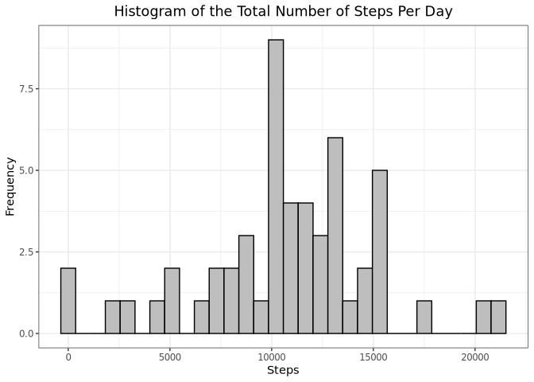

```r
# Histogram of the total steps taken per day
total_steps_per_day %>% ggplot(aes(total_steps)) +
    geom_histogram(color = 'black', fill = 'grey') + theme_bw() +
    labs(title = 'Histogram of the Total Number of Steps Per Day',
         x = 'Steps', y = 'Frequency') +
    theme(plot.title = element_text(hjust = 0.5))
```

## What is the average daily activity pattern?

We’ll start by making a line plot of the average number of steps for each five minute interval.

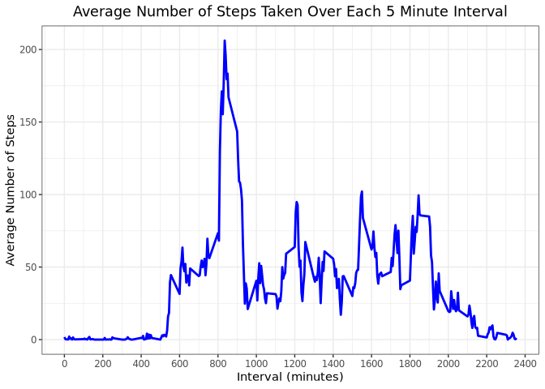

```r
# Plot the average number of steps for each five minute interval
activity_data %>% group_by(interval) %>%
    summarize(avg_steps = mean(steps, na.rm = T)) %>%
    ggplot(aes(interval, avg_steps)) +
    geom_line(color = 'blue', size = 1) +
    scale_x_continuous(breaks = seq(0, 2400, 200)) +
    theme_bw() +
    labs(title = 'Average Number of Steps Taken Over Each 5 Minute Interval',
         x = 'Interval (minutes)', y = 'Average Number of Steps') +
    theme(plot.title = element_text(hjust = 0.5))
```

From the plot we can see that the interval with the largest average number of steps is around 830.

## Imputing missing values

Before we attempt to imput missing values, let’s count just how many rows with missing values there are in our dataset.

```r
# Get the total number of missing values in the dataset
activity_data %>% is.na() %>% sum()
```

```
## [1] 2304
```

Since this is a comparatively small number of rows and we know that the missing values are all in the steps column, we can employ a simple method of imputing missing values, namely substituting the median value of the steps column.

```r
# Replace missing values in steps column with median
steps_median <- activity_data$steps %>% median(na.rm = T)
activity_data_imputed <- activity_data %>%
    replace_na(replace = list(steps = steps_median))

# Display the new dataframe with the imputed values
activity_data_imputed %>% head(10)
```

```
## # A tibble: 10 x 3
##    steps date       interval
##    <dbl> <date>        <dbl>
##  1     0 2012-10-01        0
##  2     0 2012-10-01        5
##  3     0 2012-10-01       10
##  4     0 2012-10-01       15
##  5     0 2012-10-01       20
##  6     0 2012-10-01       25
##  7     0 2012-10-01       30
##  8     0 2012-10-01       35
##  9     0 2012-10-01       40
## 10     0 2012-10-01       45
```

We can see here that the `NA`s in the original dataset have been replaced with the median of the `steps` column which happens to be 0. Let’s see how these imputed values affect the distribution, mean, and median of the `steps` column.

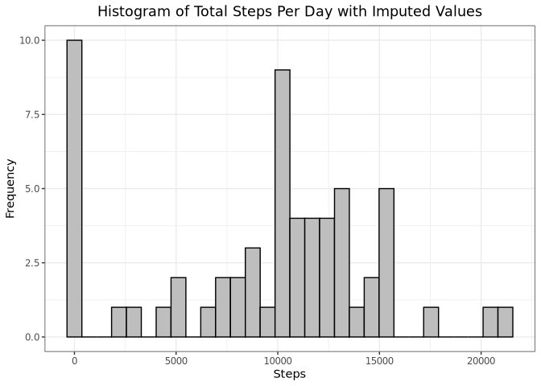

```r
# Create histogram of total number of steps taken per day
total_steps_imputed <- activity_data_imputed %>%
    group_by(date) %>%
    summarize(total_steps = sum(steps))

total_steps_imputed %>% ggplot(aes(total_steps)) +
    geom_histogram(color = 'black', fill = 'grey') +
    theme_bw() +
    labs(title = 'Histogram of Total Steps Per Day with Imputed Values',
         x = 'Steps', y = 'Frequency') +
    theme(plot.title = element_text(hjust = 0.5))
```

```r
# Calculate the mean and median total steps
total_steps_imputed %>%
    summarize(mean_total_steps = mean(total_steps),
              median_total_steps = median(total_steps))
```

```
## # A tibble: 1 x 2
##   mean_total_steps median_total_steps
##              <dbl>              <dbl>
## 1            9354.              10395
```

## Are there differences in activity patterns between weekdays and weekends?

Here we’ll need to compute the interval averages with the imputed data seperately for weekdays and weekends before plotting the values

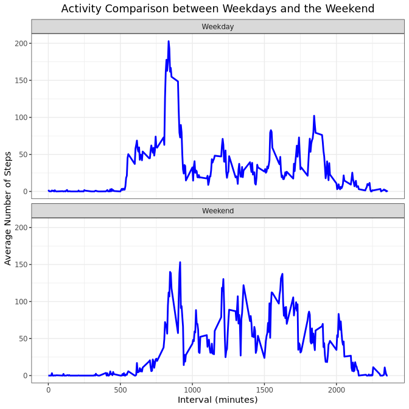

```r
# Compute average steps per interval using the imputed data differentiating
# between weekdays and weekends and plot the resulting values
activity_data_imputed %>%
    mutate(type_of_day = ifelse(str_detect(weekdays(date), 'S(at|un)'),
                                'Weekend', 'Weekday')) %>%
    group_by(type_of_day, interval) %>%
    summarize(avg_steps = mean(steps)) %>%
    ggplot(aes(interval, avg_steps)) +
    geom_line(color = 'blue', size = 1) +
    facet_wrap(~ type_of_day, ncol = 1) +
    theme_bw() +
    labs(title = 'Activity Comparison between Weekdays and the Weekend',
         x = 'Interval (minutes)', y = 'Average Number of Steps') +
    theme(plot.title = element_text(hjust = 0.5))
```

From the plot we can see that during weekdays there was a large spike of activity during the start of the activity tracking period before the average number of steps decreased to a lower level. During the weekend the amount of activity started from almost 0 before increasing to a more or less stable level.